# Lab5

Parker Davis

2023-02-17

# Tasks

## Task 1

### Obtain Working Directory

```r
getwd()
```

```
## [1] "C:/RPACKAGES/FALL224753davi0607/MATH 4753 Labs/Lab5"
```

## Task 2

### ‘mybin’ Function from Dr. Stewart

```r
mybin=function(iter=100,n=10, p=0.5){
print(p)
sam.mat=matrix(NA,nr=n,nc=iter, byrow=TRUE)

#Create a vector for successes
succ=c()

#loop through all iterations
for( i in 1:iter){

#Fill in the matrix with values of 1 and 0 dependent on p
sam.mat[,i]=sample(c(1,0),n,replace=TRUE, prob=c(p,1-p))

#Sum the successes (1's) from the column i of sam.mat
succ[i]=sum(sam.mat[,i])
}

succ.tab=table(factor(succ,levels=0:n))

barplot(succ.tab/(iter), col=rainbow(n+1), main="Binomial simulation", xlab="Number of successes")
succ.tab/iter

}
```

### 100 Iterations

```r
mybin(iter=100,n=10, p=0.7)
```

```
## [1] 0.7
```

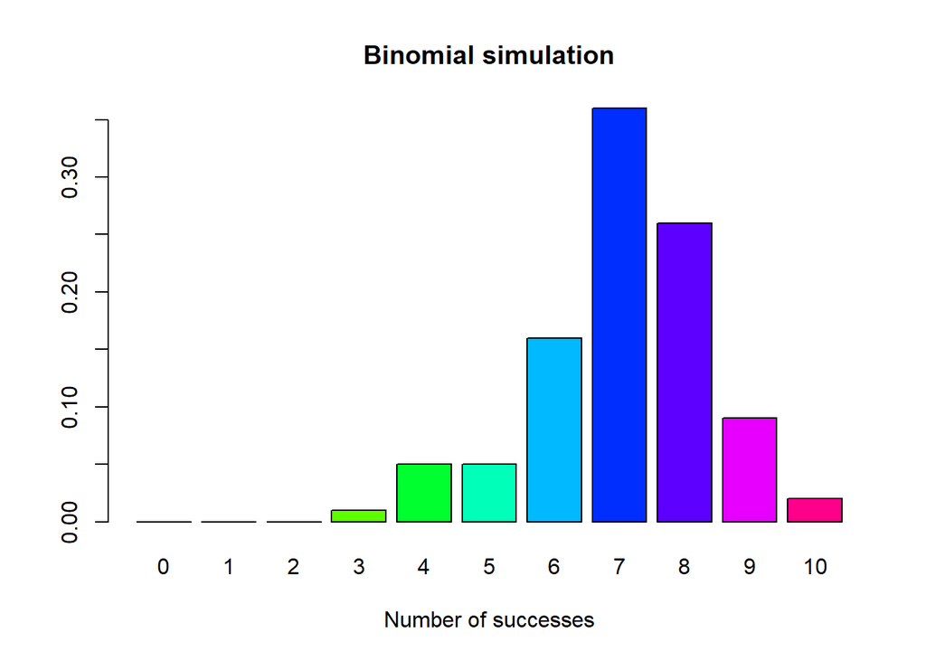

```
##
##    0    1    2    3    4    5    6    7    8    9   10
## 0.00 0.00 0.00 0.01 0.05 0.05 0.16 0.36 0.26 0.09 0.02
```

### 200 Iterations

```r
mybin(iter=200,n=10, p=0.7)
```

```
## [1] 0.7
```

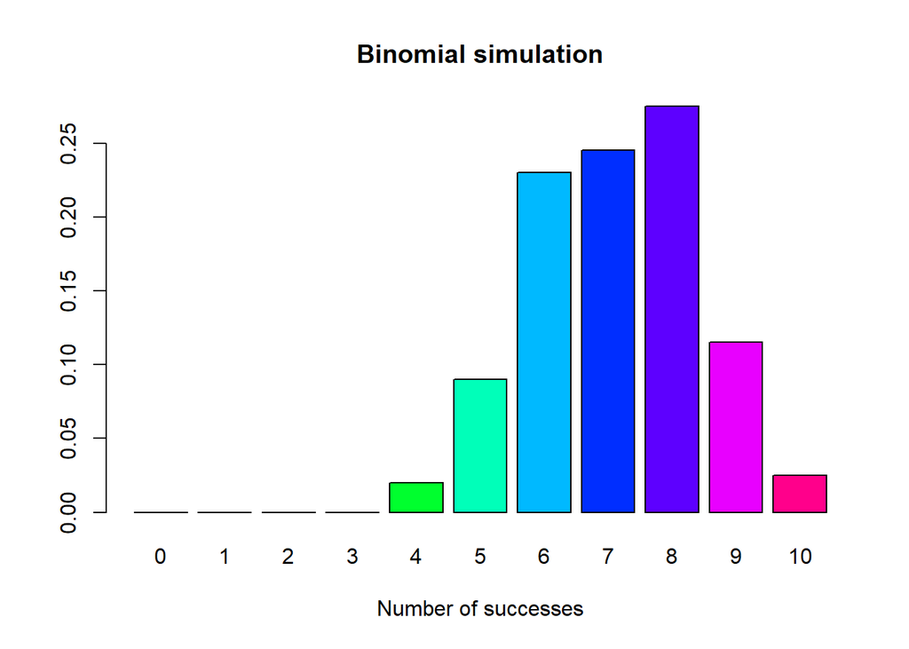

```
##
##     0     1     2     3     4     5     6     7     8     9    10
## 0.000 0.000 0.000 0.000 0.020 0.090 0.230 0.245 0.275 0.115 0.025
```

### 500 Iterations

```r
mybin(iter = 500, n = 10, p = 0.7)
```

```
## [1] 0.7
```

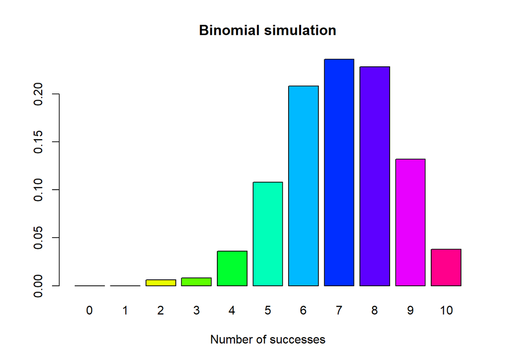

```
##
##     0     1     2     3     4     5     6     7     8     9    10
## 0.000 0.000 0.006 0.008 0.036 0.108 0.208 0.236 0.228 0.132 0.038
```

### 1000 Iterations

```r
mybin(iter=1000, n=10, p=0.7)
```

```
## [1] 0.7
```

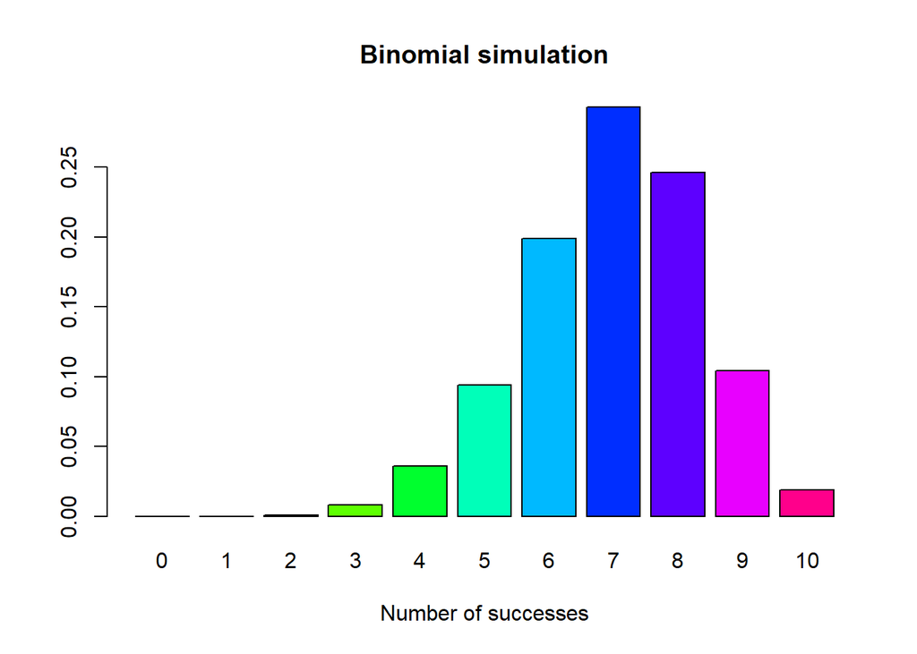

```
##
##     0     1     2     3     4     5     6     7     8     9    10
## 0.000 0.000 0.001 0.008 0.036 0.094 0.199 0.293 0.246 0.104 0.019
```

### 10,000 Iterations

```r
tab = mybin(iter=10000, n=10, p = 0.7)
```

```
## [1] 0.7
```

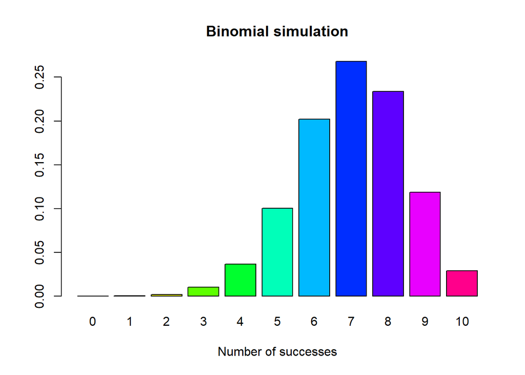

### 10000 Iteration Table

```r
tab
```

```
##
##      0      1      2      3      4      5      6      7      8      9     10
## 0.0000 0.0002 0.0018 0.0099 0.0365 0.1003 0.2020 0.2681 0.2338 0.1185 0.0289
```

### dbinom() Verification

```r
dbin = dbinom(0:10, 10, 0.7)
dbinTab = round((dbin), 4)
names(dbinTab)<- 0:10
dbinTab
```

```
##      0      1      2      3      4      5      6      7      8      9     10
## 0.0000 0.0001 0.0014 0.0090 0.0368 0.1029 0.2001 0.2668 0.2335 0.1211 0.0282
```

As we can see, the values given in the table by the dbinom() function closely resemble the values in table we created with the mybin() function!

## Task 3

### Creating a Sample w/o Replacement

```r
bagomarbles = function(numMarbles, whiteMarbs, blackMarbs){
marbles <- vector(mode="integer", length = numMarbles)
blackMarbs = blackMarbs + whiteMarbs
for(i in 1:length(marbles))
{
  if (i<=whiteMarbs)
    marbles[i] = 1
  if(i>whiteMarbs & i<=blackMarbs)
    marbles[i] = 0
}
print("1 represents white marbles, 0 represents black marbles")
print("Bag of marbles:")
print(marbles)
}
#bagomarbles(20, 12, 8)
#This is the sample:
sample(bagomarbles(20, 12, 8),size=5, replace=FALSE)
```

```
## [1] "1 represents white marbles, 0 represents black marbles"
## [1] "Bag of marbles:"
##  [1] 1 1 1 1 1 1 1 1 1 1 1 1 0 0 0 0 0 0 0 0
```

```
## [1] 1 1 0 0 1
```

### Creating a Sample With Replacement

```r
sample(bagomarbles(20,12,8), size = 5, replace = TRUE)
```

```
## [1] "1 represents white marbles, 0 represents black marbles"
## [1] "Bag of marbles:"
##  [1] 1 1 1 1 1 1 1 1 1 1 1 1 0 0 0 0 0 0 0 0
```

```
## [1] 1 1 0 1 1
```

### ‘myhyper()’ Function

```r
myhyper=function(iter=100,N=20,r=12,n=5, tab = TRUE){
# make a matrix to hold the samples
#initially filled with NA's
sam.mat=matrix(NA,nr=n,nc=iter, byrow=TRUE)
#Make a vector to hold the number of successes over the trials
succ=c()
for( i in 1:iter){
#Fill each column with a new sample
sam.mat[,i]=sample(rep(c(1,0),c(r,N-r)),n,replace=FALSE)
#Calculate a statistic from the sample (this case it is the sum)
succ[i]=sum(sam.mat[,i])
}
#Make a table of successes
succ.tab=table(factor(succ,levels=0:n))
#Make a barplot of the proportions
barplot(succ.tab/(iter), col=rainbow(n+1), main="HYPERGEOMETRIC simulation", xlab="Number of successes")

#Make an option to display the table of successes (fraction of 1)
if(tab == TRUE)
{
  return(succ.tab/iter)
}

}
```

### Barplots of White Marble Successes over Iteration

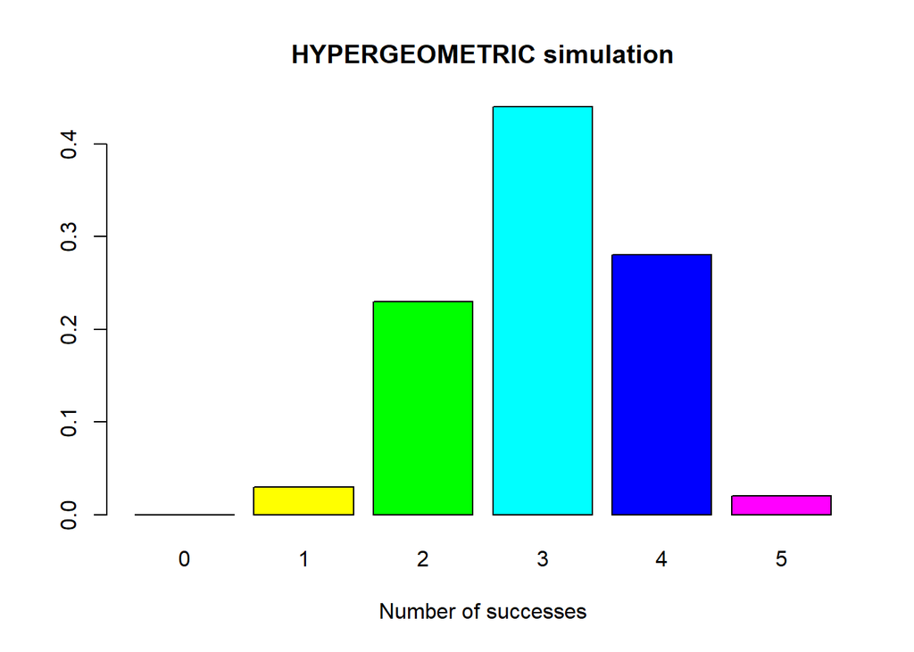

```r
#Iterate 100 times, total num of marbles = 20, number of whites = 12, take 5 samples
myhyper(iter = 100, N = 20, r = 12, n = 5, tab = FALSE)
```

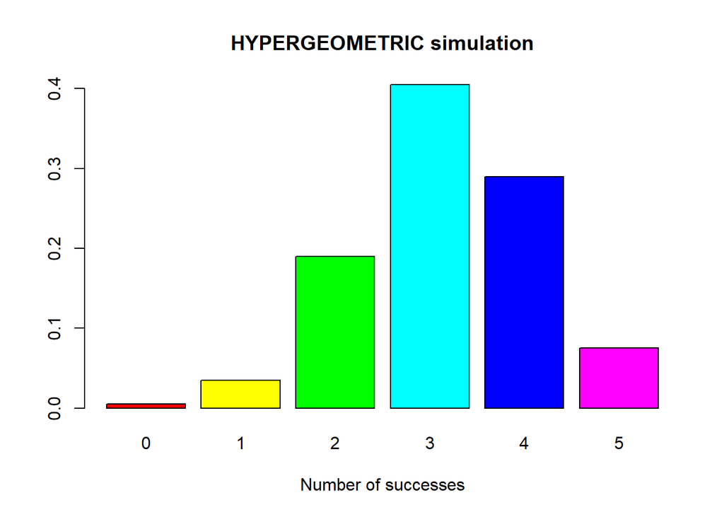

```r
myhyper(iter = 200, N = 20, r = 12, n = 5, tab = FALSE)
```

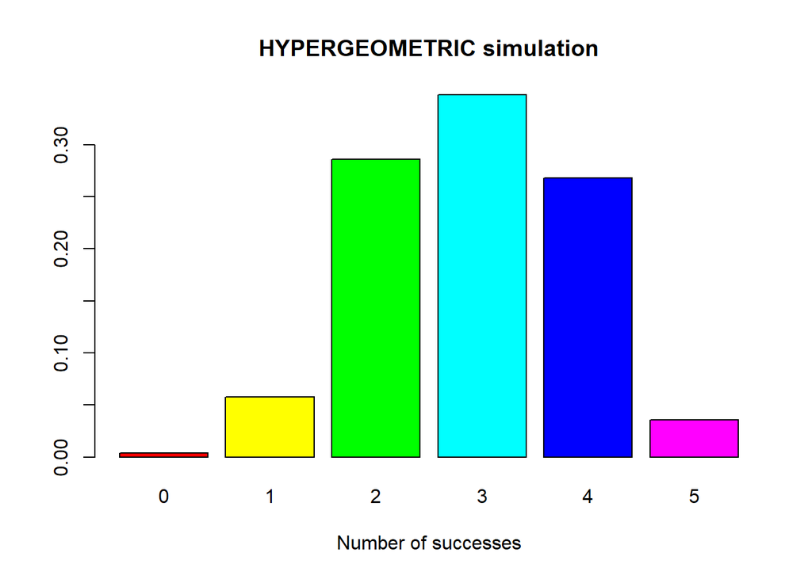

```r
myhyper(iter = 500, N = 20, r = 12, n = 5, tab = FALSE)
```

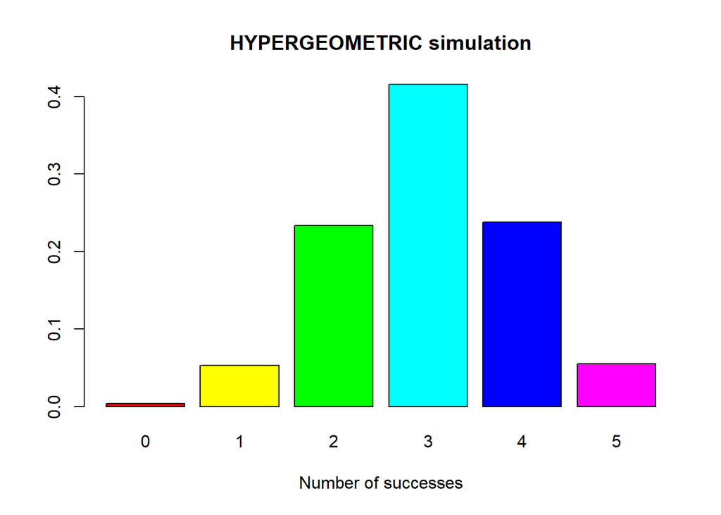

```r
myhyper(iter = 1000, N = 20, r = 12, n = 5, tab = FALSE)
```

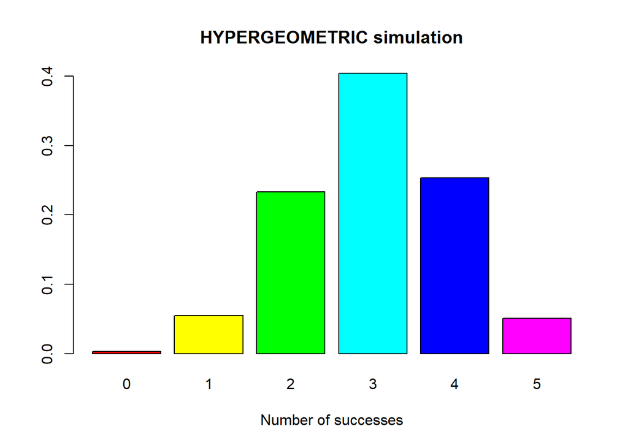

```
##
##      0      1      2      3      4      5
## 0.0033 0.0550 0.2332 0.4042 0.2536 0.0507
```

```r
myhyper(iter = 10000, N = 20, r = 12, n = 5, tab = TRUE)
```

### Verifying output

```r
dhyper(0:5, 12, 8, 5, log = FALSE)
```

```
## [1] 0.003611971 0.054179567 0.238390093 0.397316821 0.255417957 0.051083591
```

As we can see, the values output by the dhyper() function closely resemble those values that we received from the table of ‘succ.tab/iter’ from the myhyper() function!

## Task 4

### ‘mysample()’ Function

Just looking at this function, I can see that it involves taking a random sample of n out of 10 numbers, and then make a factor of that sample. I think that the time part might represent taking a different sample after a certain amount of time, but I am not sure. Maybe it makes as many samples as can fit within the time frame you specify?

```r
mysample=function(n, iter=10,time=0.5){
for( i in 1:iter){
#make a sample
s=sample(1:10,n,replace=TRUE)
# turn the sample into a factor
sf=factor(s,levels=1:10)
#make a barplot
barplot(table(sf)/n,beside=TRUE,col=rainbow(10),
main=paste("Example sample()", " iteration ", i, " n= ", n,sep="") ,
ylim=c(0,0.2)
)

#release the table
Sys.sleep(time)
}
}
```

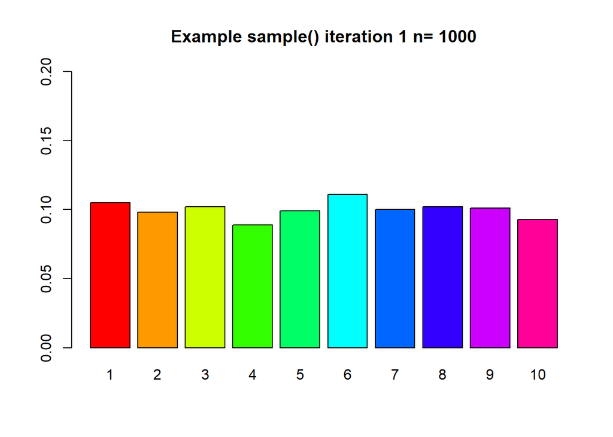

```r
mysample(n = 1000, iter = 1, time = 1)
```

It looks like this mysample() function iterated and created a new sample every 1 to 2 seconds, over the course of 30 iterations. It then created a plot for each iteration, just like with the other functions we have created. It also took 1000 samples of the 1-10 values, and returned in the plot the percentage of successes out of all the responses.  
I would compare the mysample function to dice rolling, as each value has an equal probability.

NOTE: I could not figure out how to display just one plot out of the 30, so I changed the iterations to just 1 to display only one plot.

## Task 5

### Combination

```r
choose(8,4)
```

```
## [1] 70
```

```r
1-ppois(4, lambda = 2)
```

```
## [1] 0.05265302
```

```r
dnbinom(7,3,0.4)
```

```
## [1] 0.06449725
```

```r
pbinom(8, 15, 0.4)
```

```
## [1] 0.9049526
```

## Task 6

### Bag of Marbles Function

```r
FALL224753davi0607::bagomarbles(25,14,11)
```

```
## [1] "1 represents white marbles, 0 represents black marbles"
## [1] "Bag of marbles:"
##  [1] 1 1 1 1 1 1 1 1 1 1 1 1 1 1 0 0 0 0 0 0 0 0 0 0 0
```

```
##  [1] 1 1 1 1 1 1 1 1 1 1 1 1 1 1 0 0 0 0 0 0 0 0 0 0 0
```

```r
newbag <- FALL224753davi0607::bagomarbles(25,14,11)
```

```
## [1] "1 represents white marbles, 0 represents black marbles"
## [1] "Bag of marbles:"
##  [1] 1 1 1 1 1 1 1 1 1 1 1 1 1 1 0 0 0 0 0 0 0 0 0 0 0
```

```r
newbag[1]
```

```
## [1] 1
```

### mybinom Function

```r
FALL224753davi0607::binom(10000,10,.6)
```

```
## [1] 0.6
```

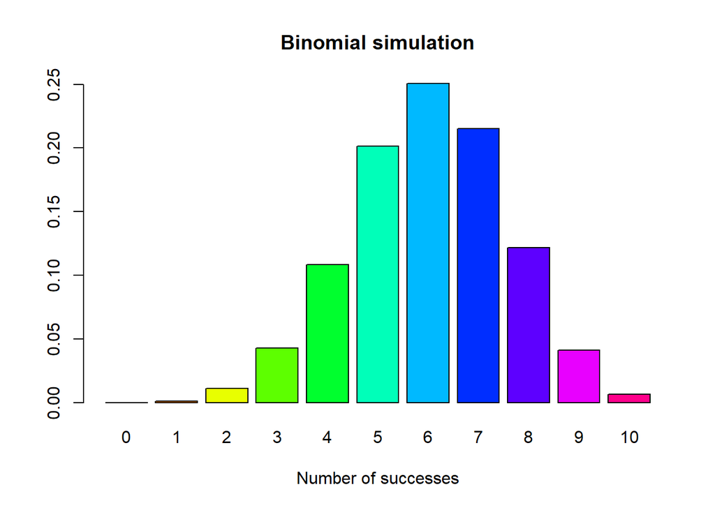

```
##
##      0      1      2      3      4      5      6      7      8      9     10
## 0.0000 0.0011 0.0113 0.0429 0.1082 0.2013 0.2507 0.2153 0.1218 0.0410 0.0064
```

```r
dbinom(6, 10, .5)
```

```
## [1] 0.2050781
```

```r
mybin(10000, 10, .5)
```

```
## [1] 0.5
```

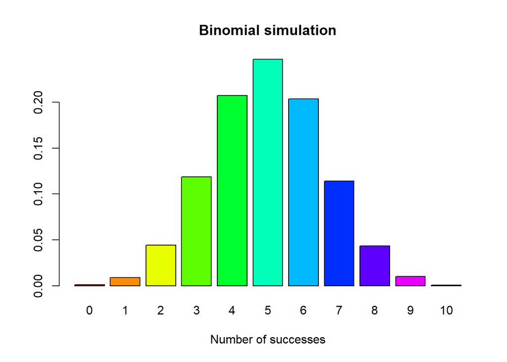

```
##
##      0      1      2      3      4      5      6      7      8      9     10
## 0.0010 0.0088 0.0443 0.1187 0.2075 0.2470 0.2040 0.1143 0.0435 0.0103 0.0006
```

```r
((pbinom(6,10,.5)) - (pbinom(3,  10, .5)))
```

```
## [1] 0.65625
```

```r
pbinom(6, 10, .5, lower.tail = FALSE)
```

```
## [1] 0.171875
```

```r
pbinom(7, 10, .5)
```

```
## [1] 0.9453125
```